# MASThesis

Devin Reeh

2025-05-22

# I. Running Variable and Cut off

What: Use school-level FRPM eligibility % as the running variable. Define one or more cutoffs (e.g., 75%, 85%, 90%) where eligibility for food or afterschool programs changes.

Why it’s important: RDD depends on a predictable rule where treatment assignment discontinuously changes at a threshold. This makes it possible to estimate causal effects near the cutoff.

How it supports your thesis: These cutoffs create a natural experiment. Schools just above and just below the FRPM threshold are comparable, allowing you to isolate the effect of the program (food or BTB) from confounding factors.

# Identify Treatement Assignment and Outcome Variables

What:

For treatment: Identify if a school participates in the food program (CEP) or the afterschool BTB program in a given year.

For outcomes: Use metrics like attendance rate, standardized test scores, or graduation rates.

Why it’s important: You need clear and measurable definitions of both the intervention (treatment) and the outcomes it is supposed to influence.

How it supports your thesis: Establishes a cause-and-effect structure — you’re asking: “Do schools just above the FRPM threshold, who get the program, show better outcomes than those just below?”

# Estimate the Treatment Effect with Local Linear Regression

What: Use local linear regression (with a small bandwidth around the cutoff) to estimate the treatment effect at the threshold.

Why it’s important: This is the core of RDD — using only schools close to the cutoff, fit a regression model that separately estimates trends from either side and captures the jump at the cutoff.

How it supports your thesis: This gives you the local average treatment effect (LATE) — the causal effect of the program on schools near the threshold. This is your key result.

# Estimate the Treatment Effect with Local Linear Regression

What: Use local linear regression (with a small bandwidth around the cutoff) to estimate the treatment effect at the threshold.

Why it’s important: This is the core of RDD — using only schools close to the cutoff, fit a regression model that separately estimates trends from either side and captures the jump at the cutoff.

How it supports your thesis: This gives you the local average treatment effect (LATE) — the causal effect of the program on schools near the threshold. This is your key result.

# Choose and Justify Bandwidth

What: Use data-driven methods (e.g., Imbens-Kalyanaraman or Calonico-Cattaneo-Titiunik (CCT)) to select optimal bandwidths.

Why it’s important: Bandwidth determines how many schools around the cutoff are included in the regression. Too wide = biased; too narrow = noisy.

How it supports your thesis: Justifying bandwidths ensures credible identification and protects against cherry-picking results. It gives your estimates scientific rigor.

# Interpret and Contextualize the Results

What: Quantify the effect size (e.g., “BTB increases attendance by 1.5% for schools near 75% FRPM cutoff”) and discuss policy implications.

Why it’s important: You’re connecting statistical results to real-world meaning — which is the goal of your thesis.

How it supports your thesis: You can now confidently argue that FRPM-based eligibility cutoffs caused changes in outcomes — backing your case that these programs have measurable benefits (or not).

[output not shown]

```r
data
```

```
## # A tibble: 13,101 × 23
##    school_name.x  school_code frpm_rate schoolcode Academic.Year Aggregate.Level
##    <chr>          <chr>           <dbl> <chr>      <chr>         <chr>
##  1 ABRAHAM LINCO… 1935121         0.953 1935121    2021-22       S
##  2 ABRAHAM LINCO… 1935121         0.953 1935121    2021-22       S
##  3 ABRAHAM LINCO… 1935121         0.953 1935121    2021-22       S
##  4 ABRAHAM LINCO… 1935121         0.953 1935121    2021-22       S
##  5 ABRAHAM LINCO… 1935121         0.953 1935121    2021-22       S
##  6 ABRAHAM LINCO… 1935121         0.953 1935121    2021-22       S
##  7 ABRAHAM LINCO… 1935121         0.953 1935121    2021-22       S
##  8 ABRAHAM LINCO… 1935121         0.953 1935121    2021-22       S
##  9 ABRAHAM LINCO… 1935121         0.953 1935121    2021-22       S
## 10 ABRAHAM LINCO… 1935121         0.953 1935121    2021-22       S
## # ℹ 13,091 more rows
## # ℹ 17 more variables: County.Code <int>, District.Code <int>,
## #   County.Name <chr>, district_name <chr>, school_name.y <chr>,
## #   Charter.School <chr>, DASS <chr>, Reporting.Category <chr>,
## #   ChronicAbsenteeismEligibleCumulativeEnrollment <dbl>,
## #   ChronicAbsenteeismCount <dbl>, chronic_absenteeism <dbl>, treated <dbl>,
## #   running <dbl>, SchoolYear <chr>, BeforeSchoolGrantProgram <int>, …
```

```r
filtered_data <- data %>%
  filter(frpm_rate >= 0.7, frpm_rate <= 0.8, btb_participation == 1)

data %>%
  filter(frpm_rate > 0.75) %>%
  summarise(
    participated = sum(btb_participation == 1, na.rm = TRUE),
    not_participated = sum(btb_participation == 0, na.rm = TRUE),
    missing = sum(is.na(btb_participation))
  )
```

```
## # A tibble: 1 × 3
##   participated not_participated missing
##          <int>            <int>   <int>
## 1         7714              638    1166
```

```r
data %>%
  filter(frpm_rate <= 0.75, frpm_rate >= 0.7) %>%
  summarise(
    participated = sum(btb_participation == 1, na.rm = TRUE),
    not_participated = sum(btb_participation == 0, na.rm = TRUE),
    missing = sum(is.na(btb_participation))
  )
```

```
## # A tibble: 1 × 3
##   participated not_participated missing
##          <int>            <int>   <int>
## 1          375               58      18
```

```r
filtered_data
```

```
## # A tibble: 750 × 23
##    school_name.x  school_code frpm_rate schoolcode Academic.Year Aggregate.Level
##    <chr>          <chr>           <dbl> <chr>      <chr>         <chr>
##  1 ALDAMA ELEMEN… 6015713         0.745 6015713    2021-22       S
##  2 ALDAMA ELEMEN… 6015713         0.745 6015713    2021-22       S
##  3 ALDAMA ELEMEN… 6015713         0.745 6015713    2021-22       S
##  4 ALDAMA ELEMEN… 6015713         0.745 6015713    2021-22       S
##  5 ALDAMA ELEMEN… 6015713         0.745 6015713    2021-22       S
##  6 ALDAMA ELEMEN… 6015713         0.745 6015713    2021-22       S
##  7 ALDAMA ELEMEN… 6015713         0.745 6015713    2021-22       S
##  8 ALDAMA ELEMEN… 6015713         0.745 6015713    2021-22       S
##  9 ALDAMA ELEMEN… 6015713         0.745 6015713    2021-22       S
## 10 ALDAMA ELEMEN… 6015713         0.745 6015713    2021-22       S
## # ℹ 740 more rows
## # ℹ 17 more variables: County.Code <int>, District.Code <int>,
## #   County.Name <chr>, district_name <chr>, school_name.y <chr>,
## #   Charter.School <chr>, DASS <chr>, Reporting.Category <chr>,
## #   ChronicAbsenteeismEligibleCumulativeEnrollment <dbl>,
## #   ChronicAbsenteeismCount <dbl>, chronic_absenteeism <dbl>, treated <dbl>,
## #   running <dbl>, SchoolYear <chr>, BeforeSchoolGrantProgram <int>, …
```

# II. Visualize the Discontinuity (RDD Plots)

What: Plot outcome vs. FRPM %, and check for a visible jump at the cutoff.

Why it’s important: A visual RDD plot helps validate the first sign of a causal effect. It shows whether there’s a discontinuity in outcomes at the eligibility threshold.

How it supports your thesis: If you observe a clear jump in outcomes right at the cutoff, it’s strong preliminary evidence that the program has a measurable effect.

## Identification

2.2 Quick visual check

1. Overall Relationship As FRPM eligibility increases, the general trend shows more variation in absenteeism rates, especially above 50%.

There’s high heterogeneity: schools with similar FRPM rates can have widely different absenteeism rates. This is typical in education data.

2. The RDD Cutoff at 75% The dashed line at 75% is the policy threshold: schools above it are considered “treated” (e.g., eligible for full program benefits).

Visually, you’re looking to see if there’s a “jump” in the absenteeism rate right at that line.

That suggests that being just above 75% FRPM might be associated with higher absenteeism, contrary to the expectation that programs like school food and afterschool support reduce absenteeism.

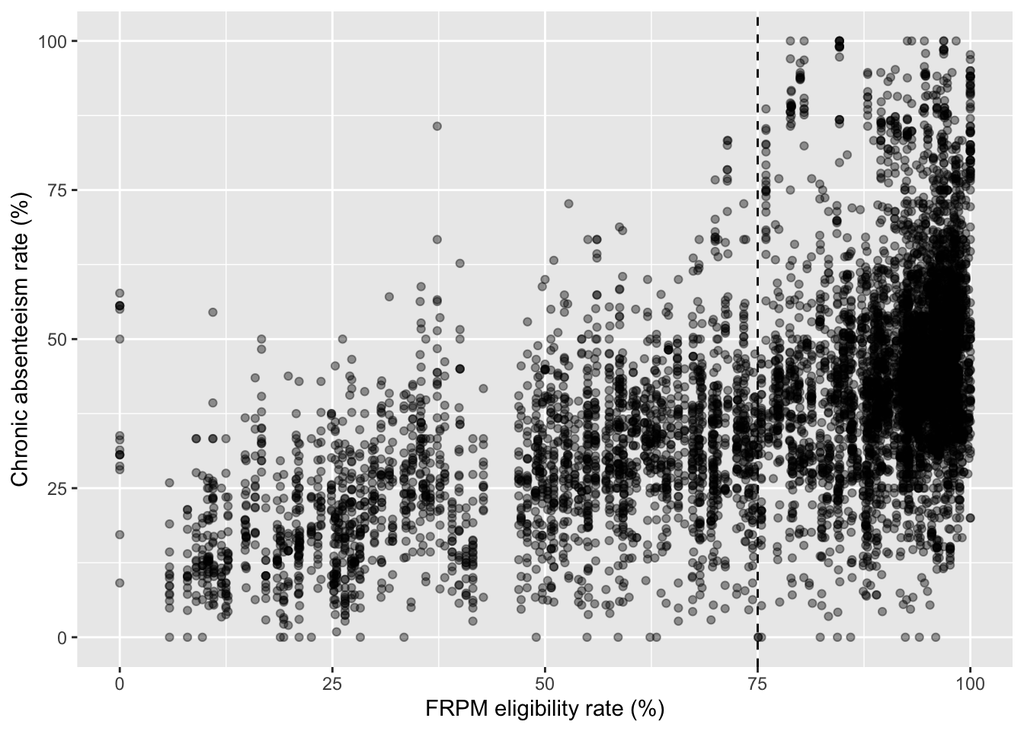

```r
library(rdrobust)
library(rddensity)

merged <- merged %>%
  mutate(
    frpm_rate = ifelse(frpm_rate <= 1, frpm_rate * 100, frpm_rate),
    running   = frpm_rate - 75,
    treated   = ifelse(frpm_rate >= 75, 1, 0)
  )

ggplot(merged, aes(frpm_rate, chronic_absenteeism)) +
  geom_point(alpha = .4) +
  geom_vline(xintercept = 75, linetype = "dashed") +
  labs(x = "FRPM eligibility rate (%)",
       y = "Chronic absenteeism rate (%)")
```

# Run the McCrary Density Test

What: Run a McCrary test to check whether schools are manipulating FRPM % to just qualify for treatment (i.e., bunching right above the cutoff).

Why it’s important: RDD assumes that units cannot precisely manipulate the running variable. If schools are “gaming” the system, the design breaks down.

How it supports your thesis: Passing the McCrary test strengthens your claim that the assignment to treatment is as-good-as-random near the threshold — key for making causal claims.

## 2.3 Test for manipulation of the running variable (McCrary test)

```r
library(rddensity)

# 1. McCrary density test
dens75 <- rddensity(merged$frpm_rate, c = 75)
dens75$test            # prints t_jk and p_jk
```

```
## $t_asy
## [1] NA
##
## $t_jk
## [1] -1.545891
##
## $p_asy
## [1] NA
##
## $p_jk
## [1] 0.1221309
```

```r
# 2. Sharp RD estimate
rd75 <- rdrobust(merged$chronic_absenteeism,
                 merged$frpm_rate,
                 c          = 75,
                 masspoints = "adjust")
summary(rd75)
```

```
## Sharp RD estimates using local polynomial regression.
##
## Number of Obs.                 8391
## BW type                       mserd
## Kernel                   Triangular
## VCE method                       NN
##
## Number of Obs.                 2615         5776
## Eff. Number of Obs.             252          309
## Order est. (p)                    1            1
## Order bias  (q)                   2            2
## BW est. (h)                   4.443        4.443
## BW bias (b)                   7.426        7.426
## rho (h/b)                     0.598        0.598
## Unique Obs.                     176          433
##
## =============================================================================
##         Method     Coef. Std. Err.         z     P>|z|      [ 95% C.I. ]
## =============================================================================
##   Conventional    10.368     1.734     5.978     0.000     [6.969 , 13.767]
##         Robust         -         -     5.446     0.000     [7.169 , 15.229]
## =============================================================================
```

```r
# 3. Density test statistics (use the right object)
dens75$test             # NOT rd75$test
```

```
## $t_asy
## [1] NA
##
## $t_jk
## [1] -1.545891
##
## $p_asy
## [1] NA
##
## $p_jk
## [1] 0.1221309
```

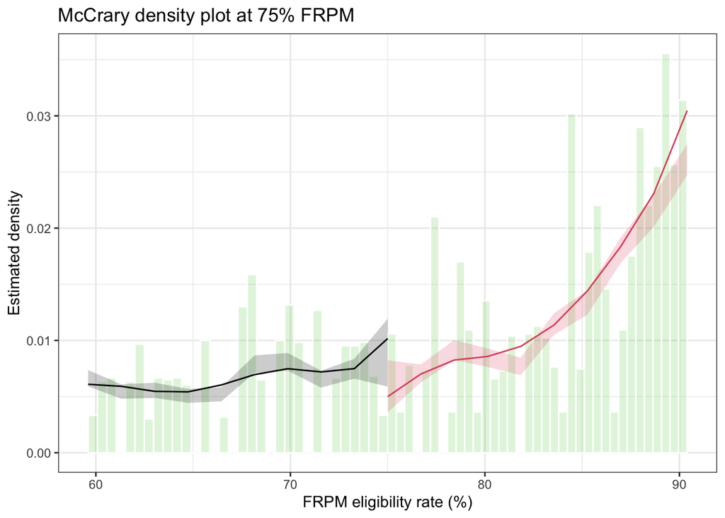

[output not shown]

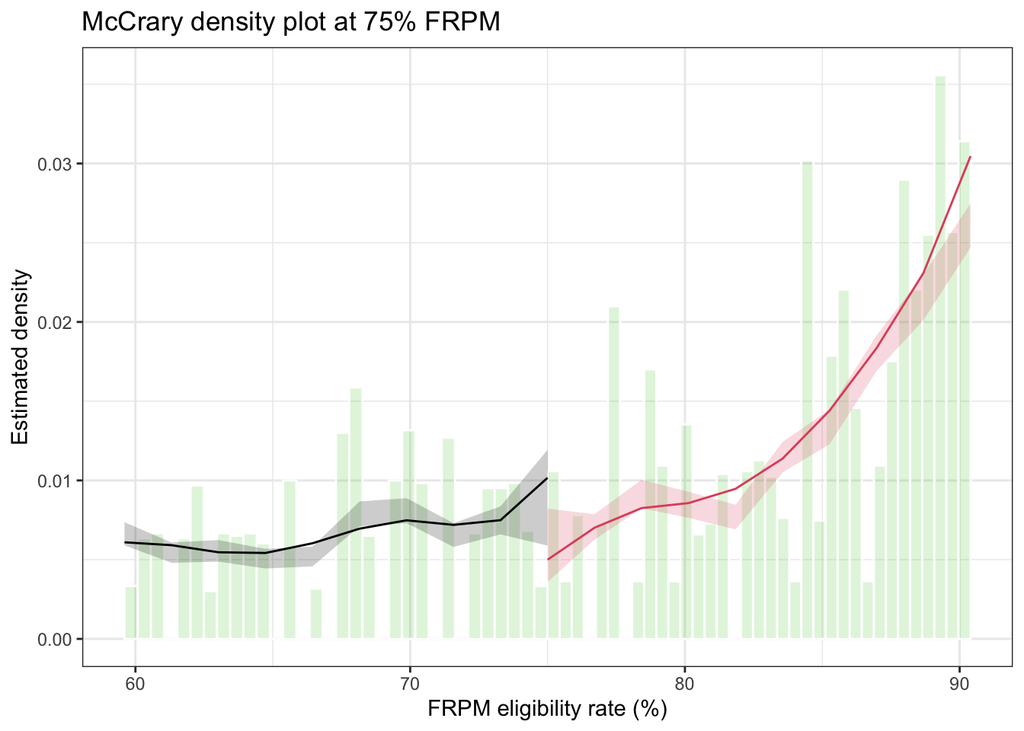

```r
# 4. McCrary density plot
# McCrary density test object
dens75 <- rddensity(merged$frpm_rate, c = 75)

# Density plot  ── rdd object first, X second ──
rdplotdensity(
  dens75,                 # ← rdd    (object returned by rddensity)
  merged$frpm_rate,       # ← X      (numeric running-variable vector)
  title  = "McCrary density plot at 75% FRPM",
  xlabel = "FRPM eligibility rate (%)",
  ylabel = "Estimated density"
)
```

Failing to reject H₀ (p > 0.05) means no evidence schools “bunch” just above the cutoff.

2.4 Covariate Balance Checks What: Test whether other school characteristics (like size, Title I status, ELL %, or student-teacher ratio) show any discontinuity at the 75% FRPM cutoff. Why: Helps ensure schools are comparable across the threshold. No jump = stronger causal claim. Where: Identification Strategy

```r
# install.packages("rdrobust")   # Only if not already installed
library(rdrobust)
names(merged)
```

```
##  [1] "school_name.x"
##  [2] "school_code"
##  [3] "frpm_rate"
##  [4] "schoolcode"
##  [5] "Academic.Year"
##  [6] "Aggregate.Level"
##  [7] "County.Code"
##  [8] "District.Code"
##  [9] "County.Name"
## [10] "district_name"
## [11] "school_name.y"
## [12] "Charter.School"
## [13] "DASS"
## [14] "Reporting.Category"
## [15] "ChronicAbsenteeismEligibleCumulativeEnrollment"
## [16] "ChronicAbsenteeismCount"
## [17] "chronic_absenteeism"
## [18] "treated"
## [19] "running"
## [20] "SchoolYear"
## [21] "BeforeSchoolGrantProgram"
## [22] "AfterSchoolGeneralFundedPrograms"
## [23] "btb_participation"
```

```r
covariates <- c("ChronicAbsenteeismEligibleCumulativeEnrollment")
                # "pct_english_learners",
                # "pct_foster_youth",
                # "pct_special_ed",
                # "pct_homeless",
                # "total_enrollment",
                # "student_teacher_ratio"

for (var in covariates) {
  cat("▶︎ Covariate:", var, "\n")

  # Run rdrobust for covariate ~ frpm_rate
  result <- rdrobust(y = merged[[var]], x = merged$frpm_rate, c = 75)

  # Print coefficient and p-value
  print(summary(result))
}
```

```
## ▶︎ Covariate: ChronicAbsenteeismEligibleCumulativeEnrollment
```

```
## Sharp RD estimates using local polynomial regression.
##
## Number of Obs.                 8391
## BW type                       mserd
## Kernel                   Triangular
## VCE method                       NN
##
## Number of Obs.                 2615         5776
## Eff. Number of Obs.             350          374
## Order est. (p)                    1            1
## Order bias  (q)                   2            2
## BW est. (h)                   5.286        5.286
## BW bias (b)                   9.080        9.080
## rho (h/b)                     0.582        0.582
## Unique Obs.                     176          433
##
## =============================================================================
##         Method     Coef. Std. Err.         z     P>|z|      [ 95% C.I. ]
## =============================================================================
##   Conventional  1060.700   277.974     3.816     0.000   [515.881 , 1605.520]
##         Robust         -         -     3.833     0.000   [560.964 , 1734.921]
## =============================================================================
## NULL
```

# Run Robustness Checks

What:

Try different bandwidths

Use polynomial order sensitivity

Conduct placebo cutoffs (e.g., use 70% or 80% as fake cutoffs)

Check covariate balance across the cutoff

Why it’s important: Confirms your results are not artifacts of model specification or sample choice.

How it supports your thesis: Robust findings across many conditions build a strong, credible argument for causal impact of the food or BTB programs.

2.5 Bandwidth Sensitivity What: Try smaller and larger windows around the cutoff (e.g., ±3%, ±7%, ±10%). Why: Tests if your results hold under different assumptions. Where: Estimation Methods + Results

```r
# Load package
library(rdrobust)

# Declare models
m1  <- rdrobust(merged$chronic_absenteeism, merged$frpm_rate, c = 75, h = 2, p = 1, masspoints = "adjust")
m2  <- rdrobust(merged$chronic_absenteeism, merged$frpm_rate, c = 75, h = 2, p = 2, masspoints = "adjust")
m3  <- rdrobust(merged$chronic_absenteeism, merged$frpm_rate, c = 75, h = 2, p = 3, masspoints = "adjust")
m4  <- rdrobust(merged$chronic_absenteeism, merged$frpm_rate, c = 75, h = 3, p = 1, masspoints = "adjust")
m5  <- rdrobust(merged$chronic_absenteeism, merged$frpm_rate, c = 75, h = 3, p = 2, masspoints = "adjust")
m6  <- rdrobust(merged$chronic_absenteeism, merged$frpm_rate, c = 75, h = 3, p = 3, masspoints = "adjust")
m7  <- rdrobust(merged$chronic_absenteeism, merged$frpm_rate, c = 75, h = 4, p = 1, masspoints = "adjust")
m8  <- rdrobust(merged$chronic_absenteeism, merged$frpm_rate, c = 75, h = 4, p = 2, masspoints = "adjust")
m9  <- rdrobust(merged$chronic_absenteeism, merged$frpm_rate, c = 75, h = 4, p = 3, masspoints = "adjust")
m10 <- rdrobust(merged$chronic_absenteeism, merged$frpm_rate, c = 75, h = 5, p = 1, masspoints = "adjust")
m11 <- rdrobust(merged$chronic_absenteeism, merged$frpm_rate, c = 75, h = 5, p = 2, masspoints = "adjust")
m12 <- rdrobust(merged$chronic_absenteeism, merged$frpm_rate, c = 75, h = 5, p = 3, masspoints = "adjust")
m13 <- rdrobust(merged$chronic_absenteeism, merged$frpm_rate, c = 75, h = 6, p = 1, masspoints = "adjust")
m14 <- rdrobust(merged$chronic_absenteeism, merged$frpm_rate, c = 75, h = 6, p = 2, masspoints = "adjust")
m15 <- rdrobust(merged$chronic_absenteeism, merged$frpm_rate, c = 75, h = 6, p = 3, masspoints = "adjust")

# Store models with correct metadata manually
model_info <- data.frame(
  name = paste0("m", 1:15),
  cutoff = 75,
  bandwidth = rep(2:6, each = 3),
  poly_order = rep(1:3, times = 5),
  stringsAsFactors = FALSE
)

models <- list(m1, m2, m3, m4, m5, m6, m7, m8, m9, m10, m11, m12, m13, m14, m15)

# Extract results and build table
robust_results <- do.call(rbind, Map(function(model, info) {
  data.frame(
    cutoff = info$cutoff,
    bandwidth = info$bandwidth,
    poly_order = info$poly_order,
    coef = model$coef[1, 1],
    se = model$se[1, 1],
    pval = model$pv[1, 1],
    ci_lower = model$ci[1, 1],
    ci_upper = model$ci[1, 2]
  )
}, models, split(model_info, seq(nrow(model_info)))))

# Show result
print(robust_results)
```

```
##    cutoff bandwidth poly_order       coef        se         pval   ci_lower
## 1      75         2          1  -2.428590  2.811263 3.876546e-01  -7.938566
## 2      75         2          2 -31.283435  5.056396 6.135728e-10 -41.193789
## 3      75         2          3 -40.774795 10.145976 5.849172e-05 -60.660543
## 4      75         3          1   8.075415  2.070939 9.643238e-05   4.016449
## 5      75         3          2  -7.387688  3.629974 4.183172e-02 -14.502306
## 6      75         3          3 -42.998963  6.160372 2.953283e-12 -55.073070
## 7      75         4          1   9.984008  1.862172 8.254047e-08   6.334218
## 8      75         4          2   1.781048  2.765611 5.195767e-01  -3.639449
## 9      75         4          3 -13.602781  4.368021 1.844601e-03 -22.163945
## 10     75         5          1  10.174908  1.625776 3.887195e-10   6.988444
## 11     75         5          2   7.326720  2.440236 2.678041e-03   2.543945
## 12     75         5          3  -8.064500  3.650360 2.715838e-02 -15.219075
## 13     75         6          1   8.156506  1.441245 1.519510e-08   5.331717
## 14     75         6          2  10.897604  2.233584 1.066379e-06   6.519859
```

[output cut: 17 more lines]

2.8 Graphical RDD Plot What: Use rdplot() to show outcome vs. running variable with fit lines. Why: Makes the discontinuity intuitive and visual. Where: Results

```
## [1] "Mass points detected in the running variable."
```

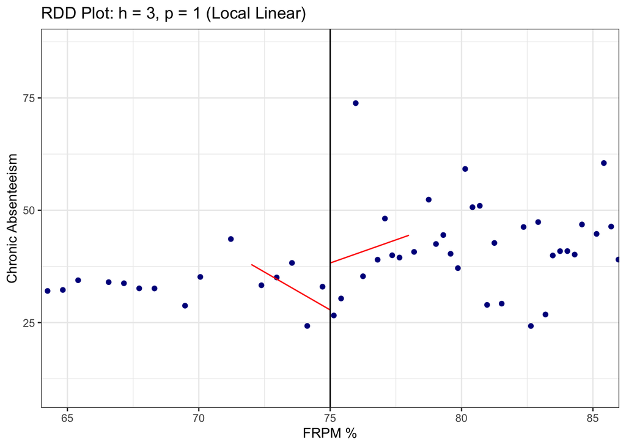

```r
# Zoomed plots for top 6 models (focusing on 65% to 85% FRPM)

library(rdrobust)

# Local linear plots zoomed in (h = 3 to 6)
rdplot(merged$chronic_absenteeism, merged$frpm_rate,
       c = 75, h = 3, p = 1,
       x.lim = c(65, 85),
       title = "RDD Plot: h = 3, p = 1 (Local Linear)",
       x.label = "FRPM %", y.label = "Chronic Absenteeism")
```

```
## [1] "Mass points detected in the running variable."
```

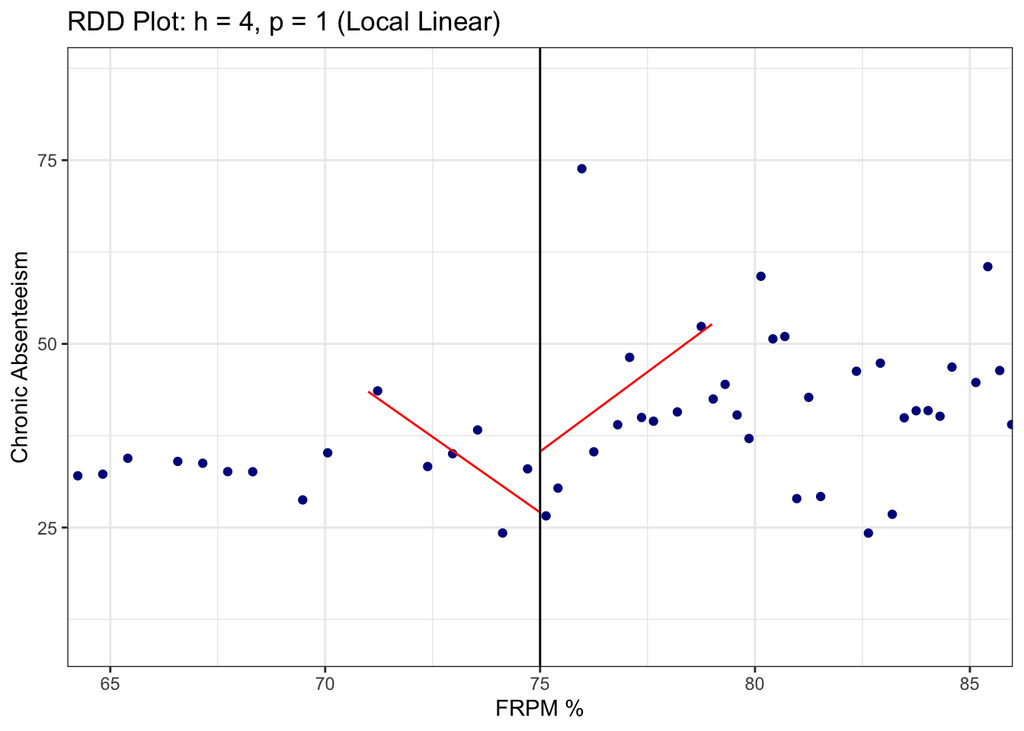

```r
rdplot(merged$chronic_absenteeism, merged$frpm_rate,
       c = 75, h = 4, p = 1,
       x.lim = c(65, 85),
       title = "RDD Plot: h = 4, p = 1 (Local Linear)",
       x.label = "FRPM %", y.label = "Chronic Absenteeism")
```

```
## [1] "Mass points detected in the running variable."
```

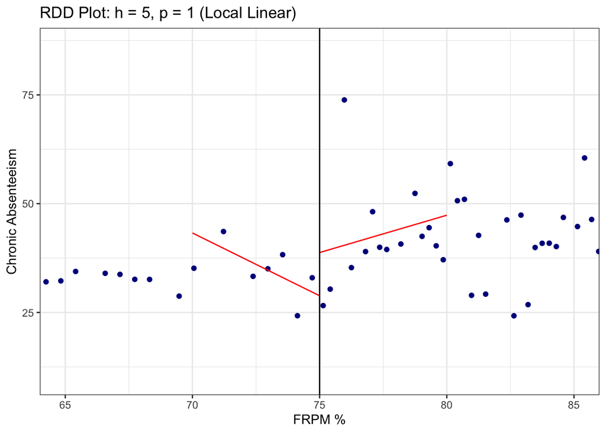

```r
rdplot(merged$chronic_absenteeism, merged$frpm_rate,
       c = 75, h = 5, p = 1,
       x.lim = c(65, 85),
       title = "RDD Plot: h = 5, p = 1 (Local Linear)",
       x.label = "FRPM %", y.label = "Chronic Absenteeism")
```

```
## [1] "Mass points detected in the running variable."
```

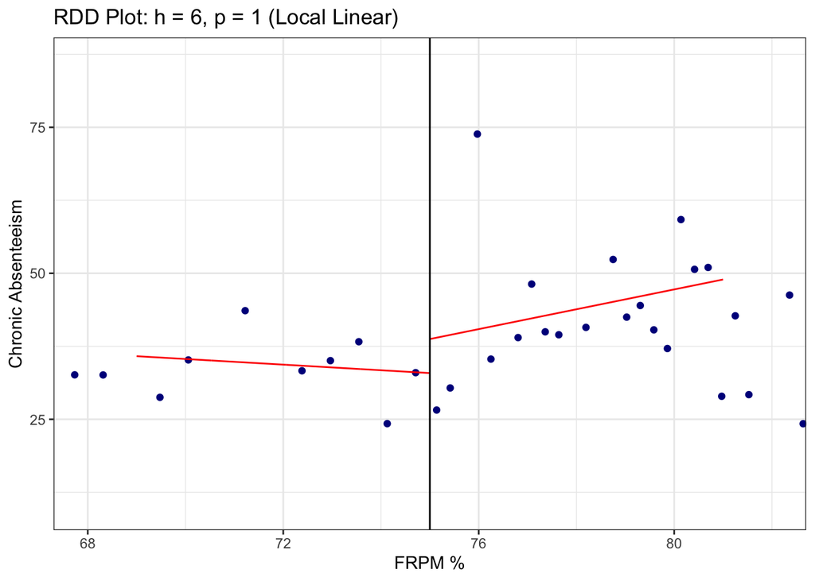

```r
rdplot(merged$chronic_absenteeism, merged$frpm_rate,
       c = 75, h = 6, p = 1,
       x.lim = c(68, 82),
       title = "RDD Plot: h = 6, p = 1 (Local Linear)",
       x.label = "FRPM %", y.label = "Chronic Absenteeism")
```